# Ride-Sharing Data Quality Analysis and Anomaly Detection

# 1. Introducción

Las plataformas de transporte bajo demanda generan volúmenes masivos de datos operacionales en tiempo real. La calidad de estos datos es fundamental para la toma de decisiones en áreas críticas como la asignación de conductores, la fijación dinámica de precios y el análisis de satisfacción del cliente.

El presente documento recoge el análisis exploratorio y depuración del dataset *NCR Ride Bookings*, que contiene 150.000 registros de viajes realizados a través de una plataforma de ride-sharing en la región de Delhi NCR (India). El dataset incluye información sobre el estado de la reserva, tiempos de espera, distancia, valor del trayecto, valoraciones de conductores y clientes, y motivos de cancelación, entre otras variables.

El objetivo principal es identificar y tratar los problemas de calidad presentes en los datos (valores ausentes, duplicados, inconsistencias y valores extremos), dejando el dataset en condiciones óptimas para un análisis posterior. A lo largo del documento se justifica cada decisión de tratamiento tomada, siguiendo los principios del análisis exploratorio riguroso.

| **Column Name** | **Description** |
| --- | --- |
| `Date` | Date of the booking |
| `Time` | Time of the booking |
| `Booking ID` | Unique identifier for each ride booking |
| `Booking Status` | Status of booking (Completed, Cancelled by Customer, Cancelled by Driver, etc.) |
| `Customer ID` | Unique identifier for customers |
| `Vehicle Type` | Type of vehicle (Go Mini, Go Sedan, Auto, eBike/Bike, UberXL, Premier Sedan) |
| `Pickup Location` | Starting location of the ride |
| `Drop Location` | Destination location of the ride |
| `Avg VTAT` | Average time for driver to reach pickup location (in minutes) |
| `Avg CTAT` | Average trip duration from pickup to destination (in minutes) |
| `Cancelled Rides by Customer` | Customer-initiated cancellation flag |
| `Reason for cancelling by Customer` | Reason for customer cancellation |
| `Cancelled Rides by Driver` | Driver-initiated cancellation flag |
| `Driver Cancellation Reason` | Reason for driver cancellation |
| `Incomplete Rides` | Incomplete ride flag |
| `Incomplete Rides Reason` | Reason for incomplete rides |
| `Booking Value` | Total fare amount for the ride |
| `Ride Distance` | Distance covered during the ride (in km) |
| `Driver Ratings` | Rating given to driver (1-5 scale) |
| `Customer Rating` | Rating given by customer (1-5 scale) |
| `Payment Method` | Method used for payment (UPI, Cash, Credit Card, Uber Wallet, Debit Card) |

# 2. Carga de datos y exploración inicial

## 2.1 Librerías

```r
library(tidyverse)   # incluye ggplot2, dplyr, readr...
library(naniar)      # visualización de missings
library(DataExplorer)
library(patchwork)
library(dbscan)
library(hms)
library(readr)
library(dplyr)
library(class)
```

## 2.2 Importación del dataset

```r
data <- read_csv("archive/ncr_ride_bookings.csv")
```

## 2.3 Primeras inspecciones

El dataset cuenta con 150.000 observaciones y 21 variables. A continuación se realiza una primera inspección para entender la estructura general antes de abordar la limpieza.

```r
glimpse(data)
```

```
Rows: 150,000
Columns: 21
$ Date                                <date> 2024-03-23, 2024-11-29, 2024-08-2…
$ Time                                <time> 12:29:38, 18:01:39, 08:56:10, 17:…
$ `Booking ID`                        <chr> "\"CNR5884300\"", "\"CNR1326809\""…
$ `Booking Status`                    <chr> "No Driver Found", "Incomplete", "…
$ `Customer ID`                       <chr> "\"CID1982111\"", "\"CID4604802\""…
$ `Vehicle Type`                      <chr> "eBike", "Go Sedan", "Auto", "Prem…
$ `Pickup Location`                   <chr> "Palam Vihar", "Shastri Nagar", "K…
$ `Drop Location`                     <chr> "Jhilmil", "Gurgaon Sector 56", "M…
$ `Avg VTAT`                          <chr> "null", "4.9", "13.4", "13.1", "5.…
$ `Avg CTAT`                          <chr> "null", "14.0", "25.8", "28.5", "1…
$ `Cancelled Rides by Customer`       <chr> "null", "null", "null", "null", "n…
$ `Reason for cancelling by Customer` <chr> "null", "null", "null", "null", "n…
$ `Cancelled Rides by Driver`         <chr> "null", "null", "null", "null", "n…
$ `Driver Cancellation Reason`        <chr> "null", "null", "null", "null", "n…
$ `Incomplete Rides`                  <chr> "null", "1", "null", "null", "null…
$ `Incomplete Rides Reason`           <chr> "null", "Vehicle Breakdown", "null…
$ `Booking Value`                     <chr> "null", "237", "627", "416", "737"…
$ `Ride Distance`                     <chr> "null", "5.73", "13.58", "34.02", …
$ `Driver Ratings`                    <chr> "null", "null", "4.9", "4.6", "4.1…
$ `Customer Rating`                   <chr> "null", "null", "4.9", "5.0", "4.3…
$ `Payment Method`                    <chr> "null", "UPI", "Debit Card", "UPI"…
```

```r
"
Las variables 'Date' y 'Time' han sido correctamente interpretadas como
<date> y <time>. Sin embargo, se observan varias variables numéricas
almacenadas como <chr>, lo que sugiere la presencia de valores interpretados incorrectamente. Esto se analizará en detalle en la sección 3. Además, variables como 'Payment Method' o 'Booking Status' deberían interpretarse como <factor>.
"
```

```
[1] "\nLas variables 'Date' y 'Time' han sido correctamente interpretadas como \n<date> y <time>. Sin embargo, se observan varias variables numéricas \nalmacenadas como <chr>, lo que sugiere la presencia de valores interpretados incorrectamente. Esto se analizará en detalle en la sección 3. Además, …
```

```r
summary(dplyr::mutate(as.data.frame(data), Time = as.character(Time)))  # hms no se resume bien con vctrs reciente
```

```
      Date                   Time            Booking ID       Booking Status
 Min.   :2024-01-01   Length   :150000   Length   :150000   Length   :150000
 1st Qu.:2024-03-31   N.unique : 62910   N.unique :148767   N.unique :     5
 Median :2024-07-01   N.blank  :     0   N.blank  :     0   N.blank  :     0
 Mean   :2024-06-30   Min.nchar:     8   Min.nchar:    12   Min.nchar:     9
 3rd Qu.:2024-09-30   Max.nchar:     8   Max.nchar:    12   Max.nchar:    21
 Max.   :2024-12-30
    Customer ID        Vehicle Type     Pickup Location     Drop Location
 Length   :150000   Length   :150000   Length   :150000   Length   :150000
 N.unique :148788   N.unique :     7   N.unique :   176   N.unique :   176
 N.blank  :     0   N.blank  :     0   N.blank  :     0   N.blank  :     0
 Min.nchar:    12   Min.nchar:     4   Min.nchar:     3   Min.nchar:     3
 Max.nchar:    12   Max.nchar:    13   Max.nchar:    25   Max.nchar:    25

      Avg VTAT           Avg CTAT      Cancelled Rides by Customer
 Length   :150000   Length   :150000   Length   :150000
 N.unique :   182   N.unique :   352   N.unique :     2
 N.blank  :     0   N.blank  :     0   N.blank  :     0
 Min.nchar:     3   Min.nchar:     4   Min.nchar:     1
 Max.nchar:     4   Max.nchar:     4   Max.nchar:     4

 Reason for cancelling by Customer Cancelled Rides by Driver
 Length   :150000                  Length   :150000
 N.unique :     6                  N.unique :     2
 N.blank  :     0                  N.blank  :     0
 Min.nchar:     4                  Min.nchar:     1
 Max.nchar:    44                  Max.nchar:     4

 Driver Cancellation Reason  Incomplete Rides  Incomplete Rides Reason
 Length   :150000           Length   :150000   Length   :150000
 N.unique :     5           N.unique :     2   N.unique :     4
 N.blank  :     0           N.blank  :     0   N.blank  :     0
 Min.nchar:     4           Min.nchar:     1   Min.nchar:     4
 Max.nchar:    35           Max.nchar:     4   Max.nchar:    17

   Booking Value      Ride Distance      Driver Ratings    Customer Rating
 Length   :150000   Length   :150000   Length   :150000   Length   :150000
 N.unique :  2567   N.unique :  4902   N.unique :    22   N.unique :    22
 N.blank  :     0   N.blank  :     0   N.blank  :     0   N.blank  :     0
 Min.nchar:     2   Min.nchar:     3   Min.nchar:     3   Min.nchar:     3
 Max.nchar:     4   Max.nchar:     5   Max.nchar:     4   Max.nchar:     4

   Payment Method
 Length   :150000
 N.unique :     6
 N.blank  :     0
 Min.nchar:     3
 Max.nchar:    11
```

# 3. Detección y tratamiento de errores

## 3.1 Tipos de variables y coherencia

```r
# Nombres corrector para la base de datos
data <- janitor::clean_names(data)
glimpse(data)
```

```
Rows: 150,000
Columns: 21
$ date                              <date> 2024-03-23, 2024-11-29, 2024-08-23,…
$ time                              <time> 12:29:38, 18:01:39, 08:56:10, 17:17…
$ booking_id                        <chr> "\"CNR5884300\"", "\"CNR1326809\"", …
$ booking_status                    <chr> "No Driver Found", "Incomplete", "Co…
$ customer_id                       <chr> "\"CID1982111\"", "\"CID4604802\"", …
$ vehicle_type                      <chr> "eBike", "Go Sedan", "Auto", "Premie…
$ pickup_location                   <chr> "Palam Vihar", "Shastri Nagar", "Kha…
$ drop_location                     <chr> "Jhilmil", "Gurgaon Sector 56", "Mal…
$ avg_vtat                          <chr> "null", "4.9", "13.4", "13.1", "5.3"…
$ avg_ctat                          <chr> "null", "14.0", "25.8", "28.5", "19.…
$ cancelled_rides_by_customer       <chr> "null", "null", "null", "null", "nul…
$ reason_for_cancelling_by_customer <chr> "null", "null", "null", "null", "nul…
$ cancelled_rides_by_driver         <chr> "null", "null", "null", "null", "nul…
$ driver_cancellation_reason        <chr> "null", "null", "null", "null", "nul…
$ incomplete_rides                  <chr> "null", "1", "null", "null", "null",…
$ incomplete_rides_reason           <chr> "null", "Vehicle Breakdown", "null",…
$ booking_value                     <chr> "null", "237", "627", "416", "737", …
$ ride_distance                     <chr> "null", "5.73", "13.58", "34.02", "4…
$ driver_ratings                    <chr> "null", "null", "4.9", "4.6", "4.1",…
$ customer_rating                   <chr> "null", "null", "4.9", "5.0", "4.3",…
$ payment_method                    <chr> "null", "UPI", "Debit Card", "UPI", …
```

```r
# FECHA Y HORA

data$date <- as.Date(data$date)
is.Date(data$date)
```

```
[1] TRUE
```

```r
data$time <- as_hms(data$time)
is_hms(data$time)
```

```
[1] TRUE
```

```r
# CAMBIO A FACTOR

data$booking_status <- as.factor(data$booking_status)
class(data$booking_status)
```

```
[1] "factor"
```

```r
levels(data$booking_status)
```

```
[1] "Cancelled by Customer" "Cancelled by Driver"   "Completed"
[4] "Incomplete"            "No Driver Found"
```

```r
data$vehicle_type <- as.factor(data$vehicle_type)
levels(data$vehicle_type)
```

```
[1] "Auto"          "Bike"          "eBike"         "Go Mini"
[5] "Go Sedan"      "Premier Sedan" "Uber XL"
```

```r
data$payment_method <- as.factor(data$payment_method)
levels(data$payment_method)
```

```
[1] "Cash"        "Credit Card" "Debit Card"  "null"        "Uber Wallet"
[6] "UPI"
```

```r
# VARIABLES NUMÉRICAS

data$avg_vtat <- as.numeric(data$avg_vtat)
data$avg_ctat <- as.numeric(data$avg_ctat)
data$booking_value <- as.numeric(data$booking_value)
data$ride_distance <- as.numeric(data$ride_distance)
data$driver_ratings <- as.numeric(data$driver_ratings)
data$customer_rating <- as.numeric(data$customer_rating)
```

```r
# VARIABLES DICOTÓMICAS

data$cancelled_rides_by_customer <- ifelse(data$cancelled_rides_by_customer == 1, 1, 0)
is.numeric(data$cancelled_rides_by_customer)
```

```
[1] TRUE
```

```r
data$cancelled_rides_by_driver <- ifelse(data$cancelled_rides_by_driver ==1, 1, 0)
is.numeric(data$cancelled_rides_by_driver)
```

```
[1] TRUE
```

```r
data$incomplete_rides <- ifelse(data$incomplete_rides == 1, 1, 0)
```

Las variables ‘Pickup Location’, y ‘Drop Location’ tienen 176 niveles en factor, por lo tanto, de momento seguirán siendo <chr>. Más adelante, podría considerar coger las direcciones más habituales para poder analizar mejor esta variable.

Las variables ‘Avg VTAT’ (Vehicle Turnaround Time) y ‘Avg CTAT’ (Customer Trip Arrival Time) representan tiempos en minutos y serán tratadas como variables numéricas continuas. Los valores ‘null’ se convierten directamente a ‘NA’.

La variable ‘booking_value’ y ‘ride_distance’ se han convertido a numérica.

Las variables ‘cancelled_rides_by_customer’ , ‘cancelled_rides_by_driver’, y ‘incomplete_rides’ tienen valores ‘null’ y ‘1’, por lo que he considerado sustituir ‘null’ por ‘0’, y dejar los valores ‘1’.

Por último, las variables ‘driver_cancellation_reason’ y ‘reason_for_cancelling_by_customer’ no se van a modificar, ya que para un análisis posterior de los motivos de cancelaciones se podrá filtrar donde la variable dicotómica sea ‘1’.

**Categorización de variables**

```r
# DRIVER_RATINGS
data$driver_ratings_factor <- cut(data$driver_ratings, breaks = c(0,1,2,3,4,5), labels = c("Pésimo", "Mal", "Normal", "Bien", "Muy bien"))
table(data$driver_ratings_factor)
```

```
  Pésimo      Mal   Normal     Bien Muy bien
       0        0      745    22271    69984
```

```r
data <- data |>
  mutate(
    driver_ratings_factor = case_when(
      driver_ratings <= 1 ~ "Pésimo",
      driver_ratings > 1 & driver_ratings <= 2 ~ "Mal",
      driver_ratings > 2 & driver_ratings <= 3 ~ "Normal",
      driver_ratings > 3 & driver_ratings <= 4 ~ "Bien",
      driver_ratings > 4 ~ 'Muy bien'
    ),
    driver_ratings_factor = factor(driver_ratings_factor, levels = c("Pésimo", "Mal", "Normal", "Bien", "Muy bien"))
  )

# CUSTOMER_RATING
data$customer_ratings_factor <- cut(data$customer_rating, breaks = c(0,1,2,3,4,5), labels = c("Pésimo", "Mal", "Normal", "Bien", "Muy bien"))
table(data$customer_ratings_factor)
```

```
  Pésimo      Mal   Normal     Bien Muy bien
       0        0      468    13620    78912
```

```r
data <- data |>
  mutate(
    customer_ratings_factor = case_when(
      customer_rating <= 1 ~ "Pésimo",
      customer_rating > 1 & customer_rating <= 2 ~ "Mal",
      customer_rating > 2 & customer_rating <= 3 ~ "Normal",
      customer_rating > 3 & customer_rating <= 4 ~ "Bien",
      customer_rating > 4 ~ 'Muy bien'
    ),
    customer_ratings_factor = factor(customer_ratings_factor, levels = c("Pésimo", "Mal", "Normal", "Bien", "Muy bien"))
  )
```

En este caso, he categorizado ‘driver_ratings’ y ‘customer_rating’ para poder analizar mejor estas variables con cinco niveles distintos: ‘Pésimo’, ‘Mal’, ‘Normal’, ‘Bien’, y ‘Muy bien’.

## 3.2 Duplicados

NIVEL 1: Empezaré mirando el primer nivel: filas completamente duplicadas.

```r
# Cuántos duplicados hay: no hay duplicados
sum(duplicated(data))
```

```
[1] 0
```

NIVEL 2: Cada reserva debería tener un único identificador.

```r
# Número de veces  con 'booking_id' repetido
data |> count(booking_id, sort = TRUE) |> filter(n > 1)
```

```
# A tibble: 1,224 × 2
   booking_id           n
   <chr>            <int>
 1 "\"CNR2726142\""     3
 2 "\"CNR3648267\""     3
 3 "\"CNR5292943\""     3
 4 "\"CNR6337479\""     3
 5 "\"CNR7199036\""     3
 6 "\"CNR7585544\""     3
 7 "\"CNR7642097\""     3
 8 "\"CNR7908610\""     3
 9 "\"CNR9603232\""     3
10 "\"CNR1026036\""     2
# ℹ 1,214 more rows
```

```r
# Comprobación de datos idénticos o no
data |> filter(booking_id == '\"CNR2726142\"')
```

```
# A tibble: 3 × 23
  date       time     booking_id       booking_status customer_id   vehicle_type
  <date>     <time>   <chr>            <fct>          <chr>         <fct>
1 2024-09-15 20:51:23 "\"CNR2726142\"" Completed      "\"CID729307… Premier Sed…
2 2024-05-22 10:58:23 "\"CNR2726142\"" Completed      "\"CID620351… Go Mini
3 2024-06-18 14:38:50 "\"CNR2726142\"" Completed      "\"CID949678… Go Sedan
# ℹ 17 more variables: pickup_location <chr>, drop_location <chr>,
#   avg_vtat <dbl>, avg_ctat <dbl>, cancelled_rides_by_customer <dbl>,
#   reason_for_cancelling_by_customer <chr>, cancelled_rides_by_driver <dbl>,
#   driver_cancellation_reason <chr>, incomplete_rides <dbl>,
#   incomplete_rides_reason <chr>, booking_value <dbl>, ride_distance <dbl>,
#   driver_ratings <dbl>, customer_rating <dbl>, payment_method <fct>,
#   driver_ratings_factor <fct>, customer_ratings_factor <fct>
```

```r
# Indicación de los duplicados con una flag
data <- data |> group_by(booking_id) |> mutate(id_duplicado = n() > 1) |>
  ungroup()

# Cuántos registros están afectados
data |> count(id_duplicado)
```

```
# A tibble: 2 × 2
  id_duplicado      n
  <lgl>         <int>
1 FALSE        147543
2 TRUE           2457
```

```r
# porcentaje
2457 / nrow(data) * 100
```

```
[1] 1.638
```

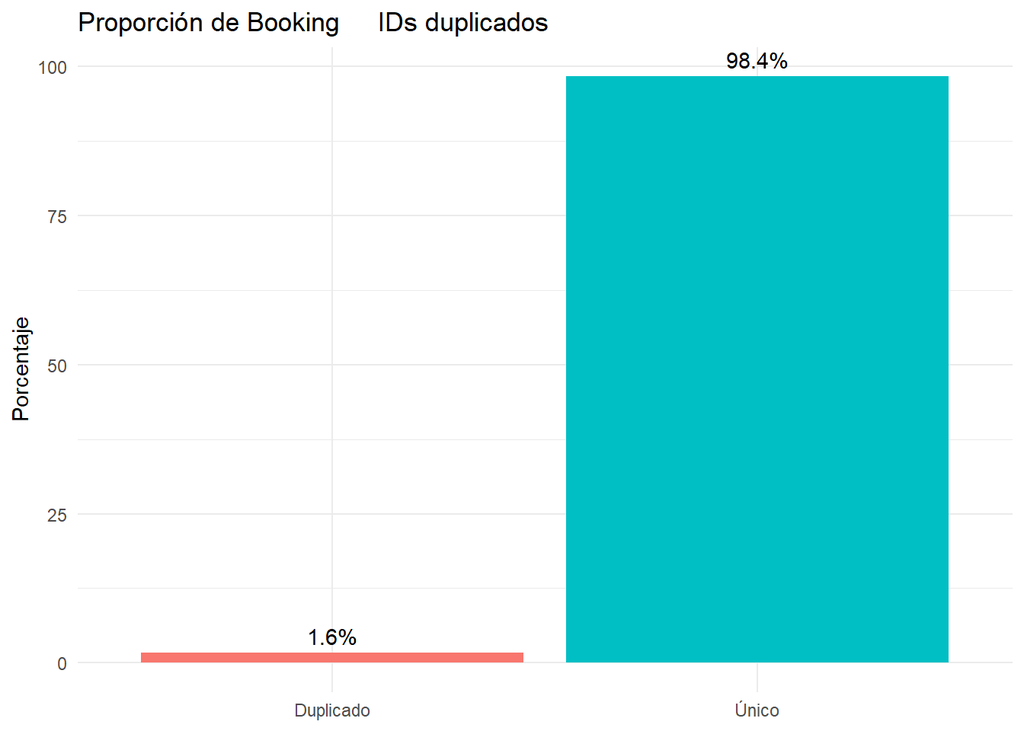

```r
# gráfico

data |> count(id_duplicado) |> mutate(porcentaje = n / sum(n) * 100, id_duplicado = if_else(id_duplicado, "Duplicado", "Único")) |>

  # gráfico representativo
  ggplot(aes(x = id_duplicado, y = porcentaje, fill = id_duplicado)) +
  geom_col() + geom_text(aes(label = paste0(round(porcentaje, 1), "%")),    vjust = -0.5) + theme_minimal() + labs(title = "Proporción de Booking     IDs duplicados", x = NULL, y = "Porcentaje") + theme(legend.position =    "none")
```

Se detectan 1.224 ‘booking_id’ duplicados cuyos registros presentan datos completamente distintos entre sí, lo que sugiere un fallo en el sistema de generación de identificadores únicos. Dado que no es posible determinar qué registro es el correcto, se opta por marcarlos mediante una variable indicadora ‘id_duplicado’ en lugar de eliminarlos o modificarlos para análisis posteriores. Esta cantidad afecta a 2.457 registros (1,6% del total).

NIVEL 3: Mismo cliente, misma fecha, misma hora, mismo destino.

```r
data |> group_by(customer_id, date, time, pickup_location, drop_location) |> filter(n() > 1) |> arrange(customer_id, date) |> ungroup()
```

```
# A tibble: 0 × 24
# ℹ 24 variables: date <date>, time <time>, booking_id <chr>,
#   booking_status <fct>, customer_id <chr>, vehicle_type <fct>,
#   pickup_location <chr>, drop_location <chr>, avg_vtat <dbl>, avg_ctat <dbl>,
#   cancelled_rides_by_customer <dbl>, reason_for_cancelling_by_customer <chr>,
#   cancelled_rides_by_driver <dbl>, driver_cancellation_reason <chr>,
#   incomplete_rides <dbl>, incomplete_rides_reason <chr>, booking_value <dbl>,
#   ride_distance <dbl>, driver_ratings <dbl>, customer_rating <dbl>, …
```

No se ha encontrado ningún caso en que el mismo cliente tuviera dos viajes registrados con idéntica fecha, hora, origen y destino, lo que descarta duplicación funcional de registros.

## 3.3 Valores imposibles o inconsistentes

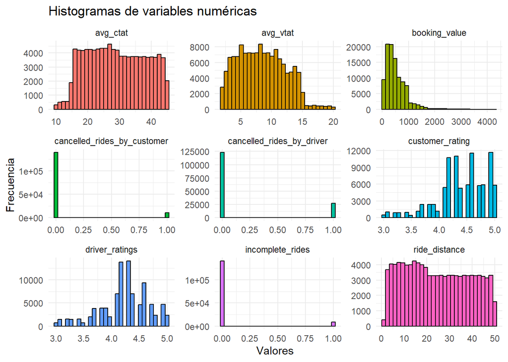

```r
data |>
select(where(is.numeric)) |>
pivot_longer(everything(), names_to = "variable", values_to = "valor") |>
ggplot(aes(x = valor, fill = variable)) +
geom_histogram(color = "black", bins = 30, show.legend = FALSE) +
facet_wrap(~variable, scales = "free") +
labs(title = "Histogramas de variables numéricas", x = "Valores", y = "Frecuencia") +
theme_minimal()
```

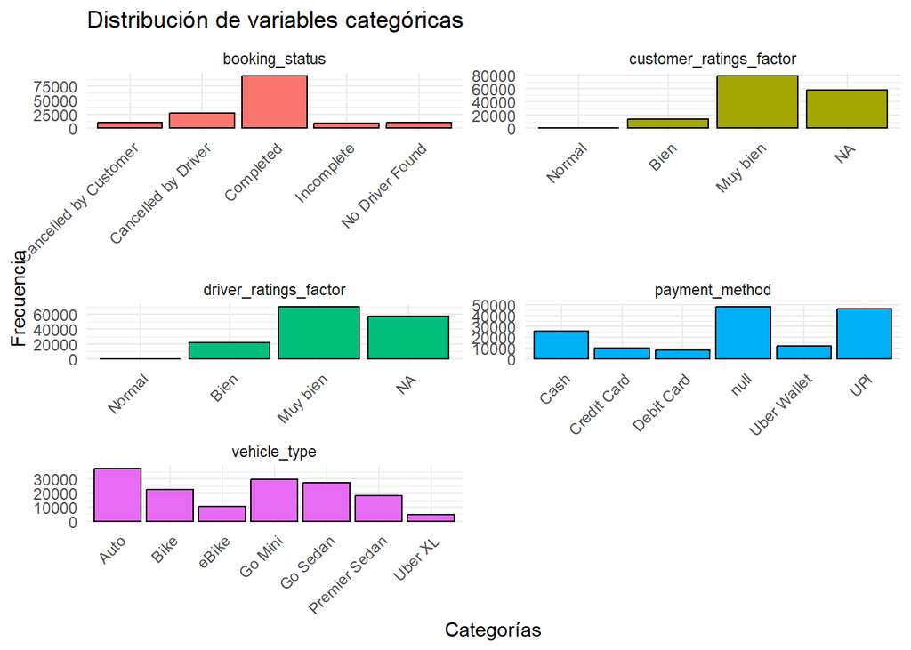

```r
data |>
select(booking_status, vehicle_type, payment_method, driver_ratings_factor, customer_ratings_factor) |>
pivot_longer(everything(), names_to = "variable", values_to = "valor") |>
ggplot(aes(x = valor, fill = variable)) +
geom_bar(color = "black") +
facet_wrap(~variable, scales = "free", ncol = 2) +
labs(
title = "Distribución de variables categóricas",
x = "Categorías",
y = "Frecuencia"
) +
theme_minimal() +
theme(
axis.text.x = element_text(angle = 45, hjust = 1),
legend.position = "none"
)
```

```r
data$payment_method <- recode(data$payment_method, 'null' = NA_character_)
```

En este caso, convertiré la ‘null’ de la variable ‘payment_method’ a NA para análisis posteriores de valores perdidos.

A partir de los histogramas de las variables numéricas no se puede ver ningún valor imposible y se observan los siguientes patrones:

**‘booking_value’** presenta una distribución claramente asimétrica con una alta concentración de valores bajos y una cola larga hacia valores elevados. Este comportamiento sugiere la existencia de valores extremos o poco frecuentes dentro de la variable.

’**ride_distance’** presenta una distribución bastante homogénea dentro de su rango sin valores negativos, ni concentraciones anómalas.

**‘cutomer_rating’ y ‘driver_ratings’** se concentran en valores altos (3, 4 y 5). El tratamiento de NA se tratará en apartados posteriores.

**‘cancelled_rides_by_customer’ y ‘cancelled_rides_by_driver’** presentan una distribución binaria (valores 0 y 1), con una predominancia del valor 0, lo que indica baja frecuencia de cancelaciones.

En cuanto a las variables categóricas, se identifican los siguientes aspectos:

’**booking_status’** muestra que la mayoría de los registros corresponden a viajes completados.

**‘payment_method’** tiene muchos valores ‘null’, por lo que habrá que considerarlo en la detección de valores faltantes.

# 4. Análisis de valores missing

## 4.1 Detección y visualización

Se analiza la presencia de valores ausentes en el dataset tras la limpieza inicial. Dado que muchas variables solo toman valor en determinadas situaciones (viaje completado, cancelación por cliente, etc.), se espera encontrar un patrón de missings estructural relacionado con ‘booking_status’.

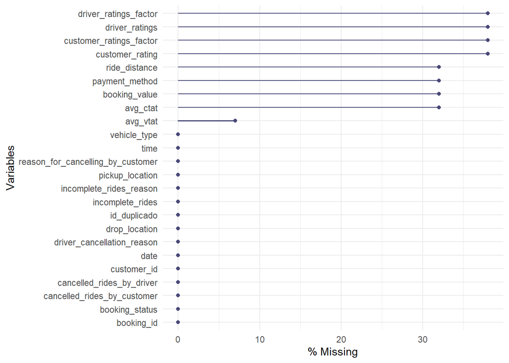

```r
# Porcentaje de missings por variable
gg_miss_var(data, show_pct = TRUE)
```

```r
# Número de celdas missing en todo el dataset
n_miss(data)
```

```
[1] 430500
```

```r
# Porcentaje de filas completas si borramos todas las filas que contienen al menos un dato missing
pct_complete_case(data)
```

```
[1] 62
```

```r
# Número de filas completas si borramos todas las filas que contienen al menos un datos missing
n_case_complete(data)
```

```
[1] 93000
```

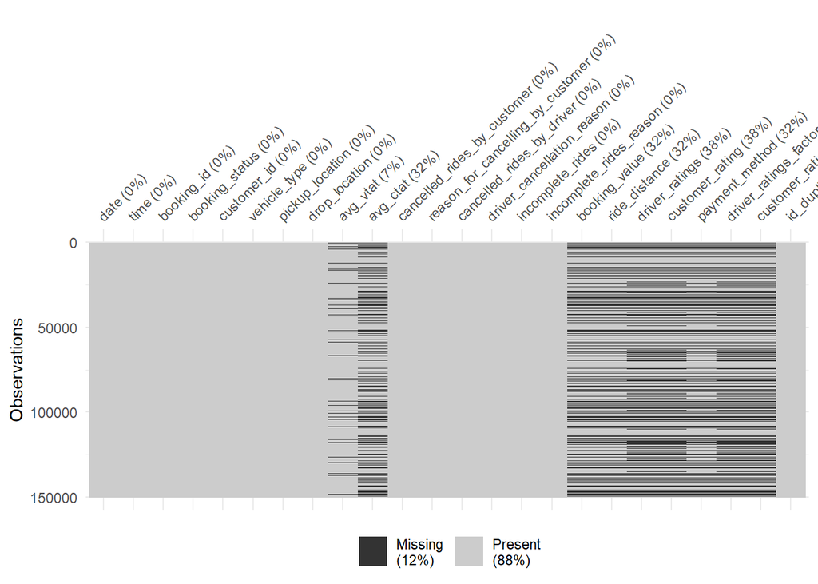

```r
# Heatmap de patrón de missings
vis_miss(data, warn_large_data = FALSE)
```

## 4.2 Patrón de missings (MCAR, MAR, MNAR)

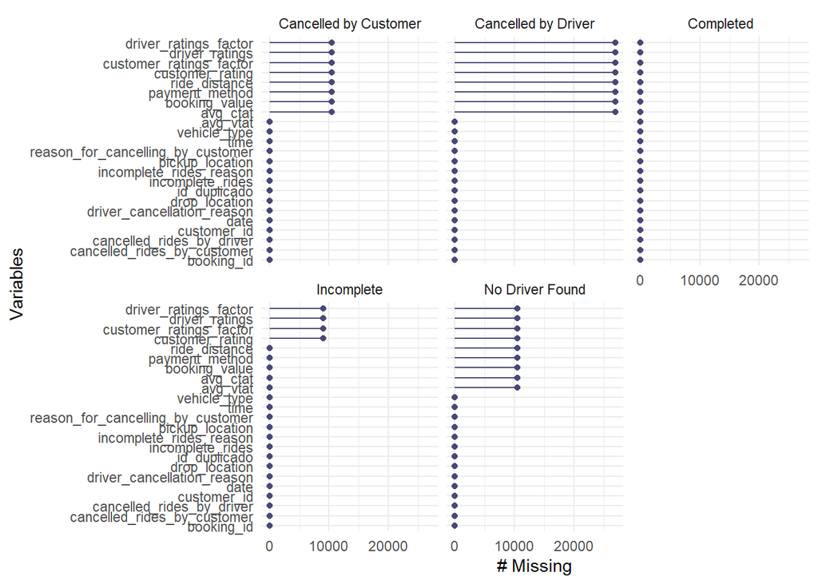

```r
# Missings por variable y por booking_status
gg_miss_var(data, facet = booking_status)
```

El análisis por ‘booking_status’ revela que los missings no son aleatorios (MCAR), sino que responden a la lógica operacional del negocio. Se trata de missings de tipo MNAR (Missing not at random). Las variables de valoración y métricas económicas presentan missings sistemáticos en viajes no completados, donde dichos valores no pueden existir por definición.

```r
data |>
  group_by(booking_status) |>
  summarise(
    missing_rating = sum(is.na(driver_ratings)),
    missing_value  = sum(is.na(booking_value)),
    missing_dist   = sum(is.na(ride_distance)),
    n = n()
  )
```

```
# A tibble: 5 × 5
  booking_status        missing_rating missing_value missing_dist     n
  <fct>                          <int>         <int>        <int> <int>
1 Cancelled by Customer          10500         10500        10500 10500
2 Cancelled by Driver            27000         27000        27000 27000
3 Completed                          0             0            0 93000
4 Incomplete                      9000             0            0  9000
5 No Driver Found                10500         10500        10500 10500
```

## 4.3 Imputaciones y justificación

IMPUTACIÓN CON MODELO DE REGRESIÓN

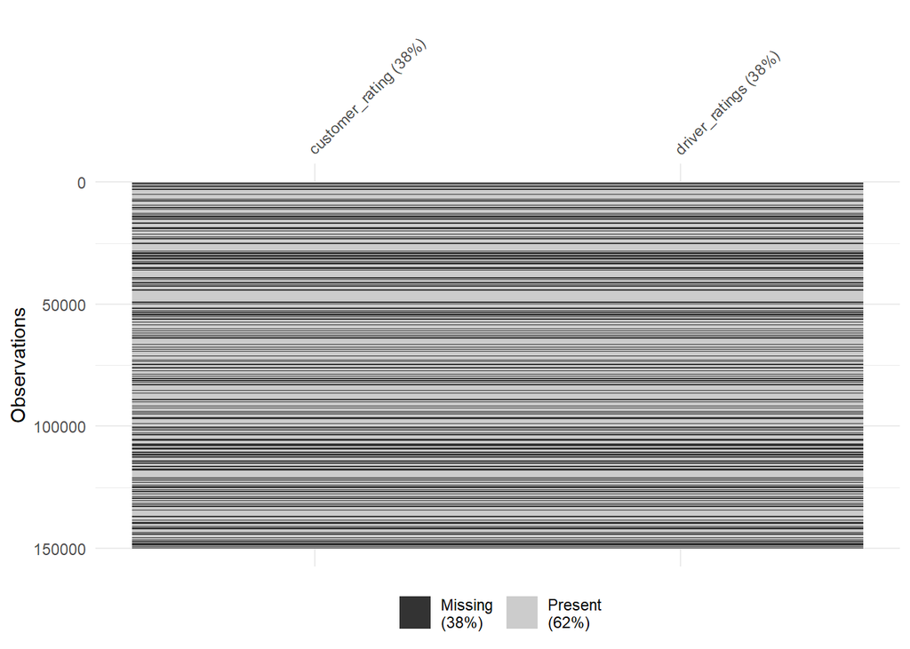

```r
library(dplyr)
vis_miss(select(data,customer_rating,driver_ratings))
```

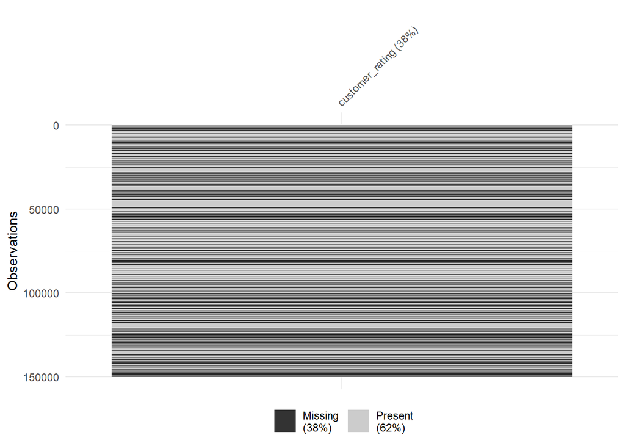

```r
vis_miss(select(data, customer_rating,))
```

```r
#Ajustar un modelo de regresión lineal de 'customer_rating' y 'driver_ratings'
model1 <- lm(customer_rating ~ driver_ratings, data = data)
summary(model1)
```

```
Call:
lm(formula = customer_rating ~ driver_ratings, data = data)

Residuals:
     Min       1Q   Median       3Q      Max
-1.40583 -0.20462  0.09417  0.39427  0.59619

Coefficients:
                Estimate Std. Error t value Pr(>|t|)
(Intercept)     4.408868   0.013978 315.412   <2e-16 ***
driver_ratings -0.001013   0.003286  -0.308    0.758
---
Signif. codes:  0 '***' 0.001 '**' 0.01 '*' 0.05 '.' 0.1 ' ' 1

Residual standard error: 0.4378 on 92998 degrees of freedom
  (57000 observations deleted due to missingness)
Multiple R-squared:  1.021e-06, Adjusted R-squared:  -9.732e-06
F-statistic: 0.09493 on 1 and 92998 DF,  p-value: 0.758
```

```r
#Predecir los valores solo para las observaciones faltantes
predictions <- predict(model1,newdata = data [is.na(data$customer_rating),])

##Crear una nueva variable de linelist con la temperatura imputada
data$customer_rating_imp_model1 <- data$customer_rating
data$customer_rating_imp_model1[is.na(data$customer_rating)]<- predictions
```

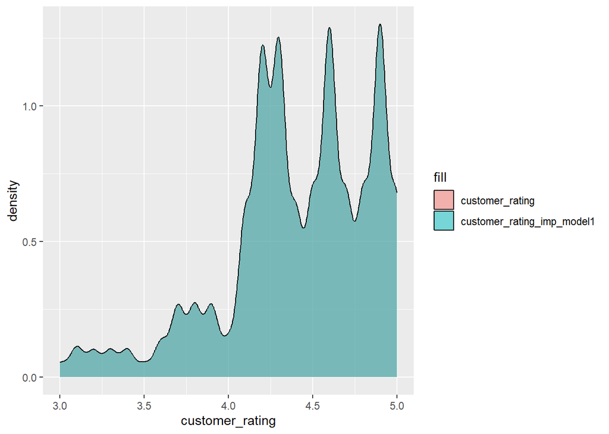

```r
#Hacer un gráfico para comparar las observaciones
ggplot(data, aes(x = customer_rating, fill = "customer_rating")) +  geom_density(alpha = 0.5) +
geom_density(aes(x = customer_rating_imp_model1, fill = "customer_rating_imp_model1"), alpha = 0.5)
```

IMPUTACIÓN CON LA MEDIA

```r
data$customer_rating_imp <- data$customer_rating #Nueva variable
mean(data$customer_rating_imp, na.rm = TRUE) #Media
```

```
[1] 4.404584
```

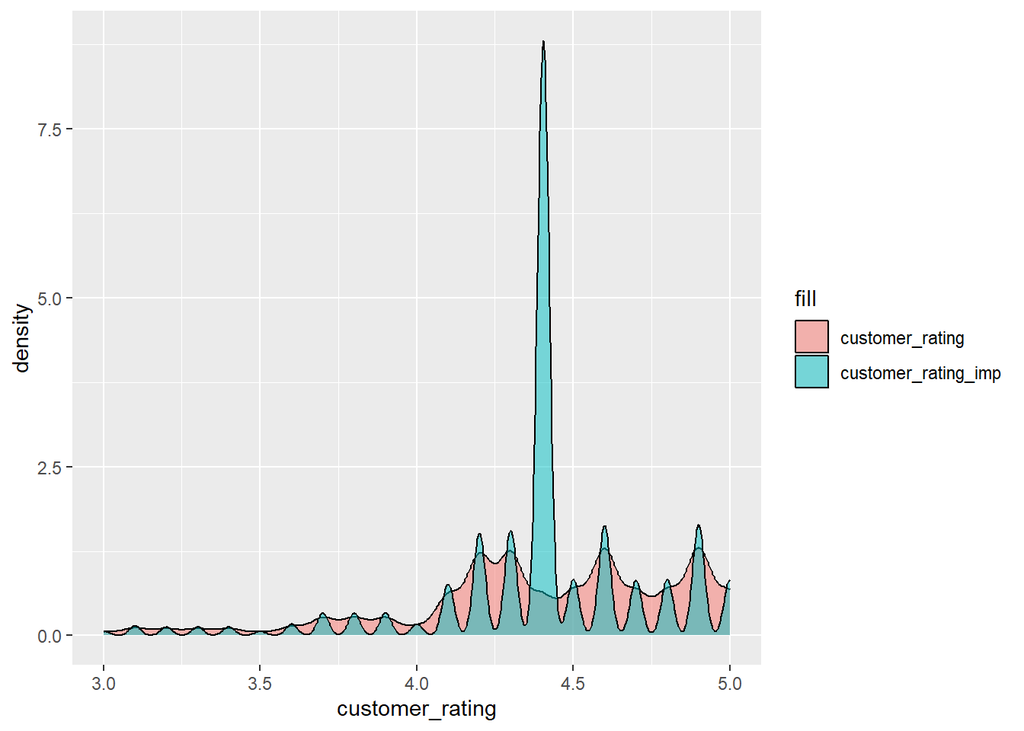

```r
# 38.55829
data$customer_rating_imp[is.na(data$customer_rating_imp)] <- mean(data$customer_rating_imp, na.rm = TRUE) #Imputación


##Gráfico para representar las diferencias
ggplot(data, aes(x = customer_rating, fill = "customer_rating")) +
geom_density(alpha = 0.5) +
geom_density(aes(x = customer_rating_imp, fill = "customer_rating_imp"), alpha = 0.5)
```

Al imputar con la media, no parece muy correcto, ya que varía mucho y se ve un pico en el valor de 4.4 aproximadamente.

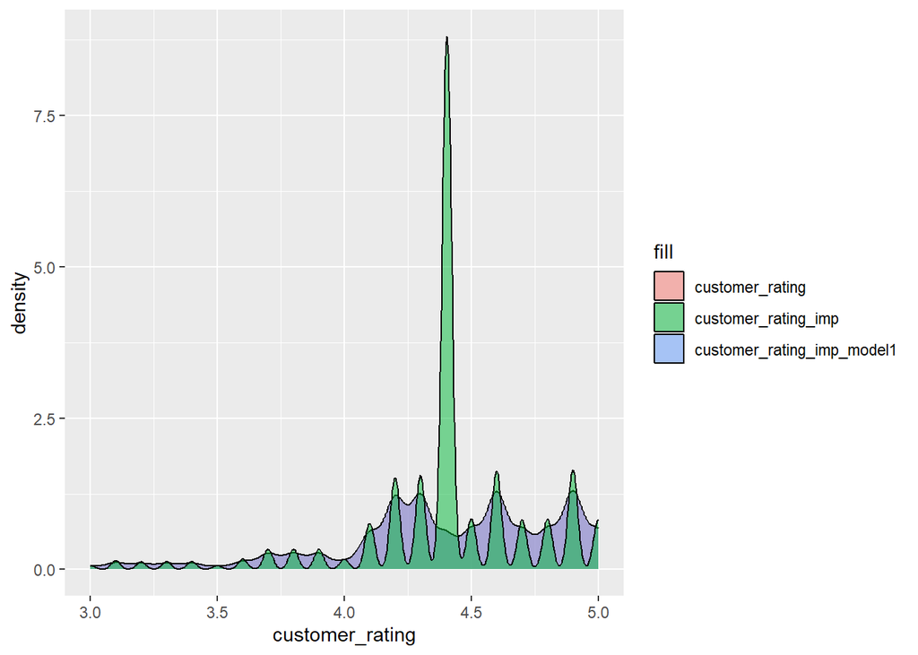

```r
# Hacer un gráfico para comparar las observaciones con la media y la regresión
ggplot(data, aes(x = customer_rating, fill = "customer_rating")) +  geom_density(alpha = 0.5) +
geom_density(aes(x = customer_rating_imp_model1, fill = "customer_rating_imp_model1"), alpha = 0.5) +
geom_density(aes(x = customer_rating_imp, fill = "customer_rating_imp"), alpha = 0.5)
```

# 5. Análisis univariante, posibles outliers y extremos.

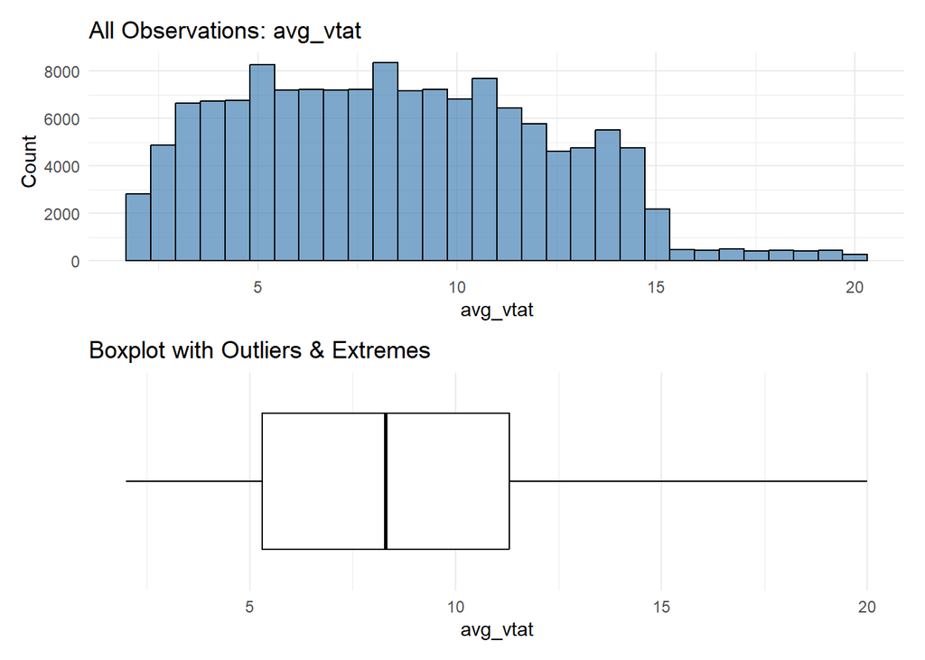

```
🟠 Atípicos (Outliers) en avg_vtat :  0
   🔸 Proporción (%): 0 %

🔴 Extremos (Extreme values) en avg_vtat :  0
   🔻 Proporción (%): 0 %
```

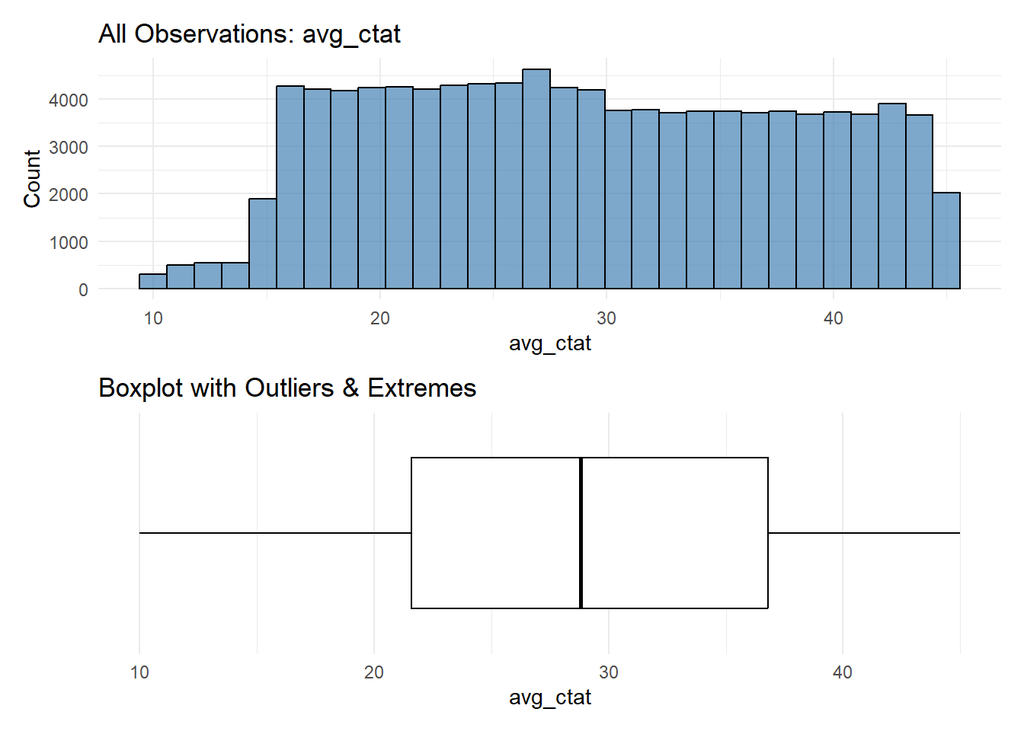

```
🟠 Atípicos (Outliers) en avg_ctat :  0
   🔸 Proporción (%): 0 %

🔴 Extremos (Extreme values) en avg_ctat :  0
   🔻 Proporción (%): 0 %
```

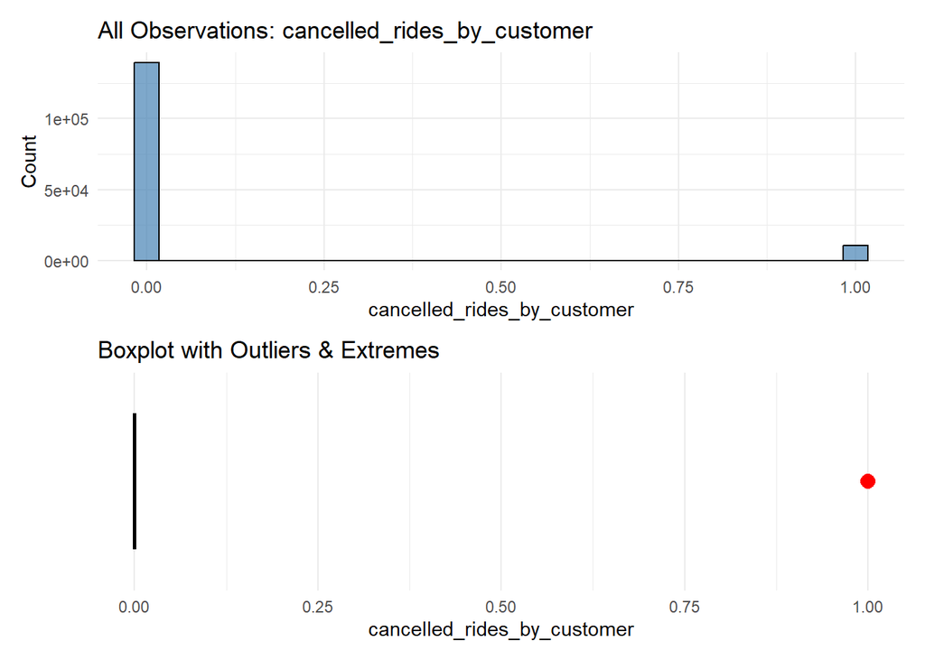

```
🟠 Atípicos (Outliers) en cancelled_rides_by_customer :  10500
   🔸 Proporción (%): 7 %

🔴 Extremos (Extreme values) en cancelled_rides_by_customer :  10500
   🔻 Proporción (%): 7 %
```

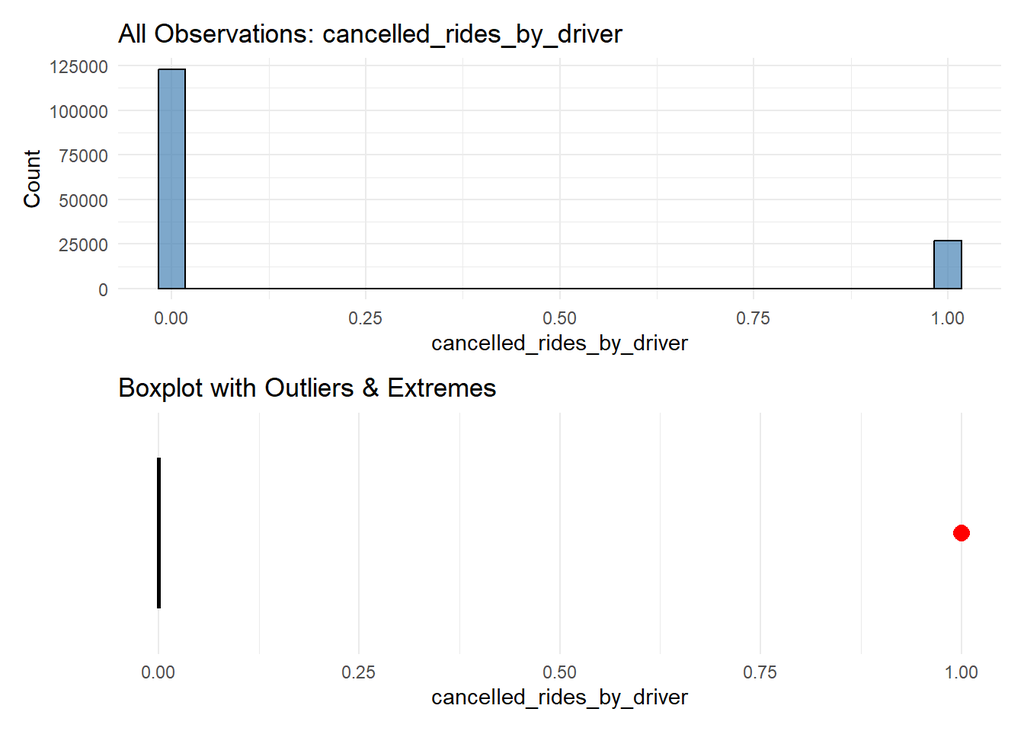

```
🟠 Atípicos (Outliers) en cancelled_rides_by_driver :  27000
   🔸 Proporción (%): 18 %

🔴 Extremos (Extreme values) en cancelled_rides_by_driver :  27000
   🔻 Proporción (%): 18 %
```

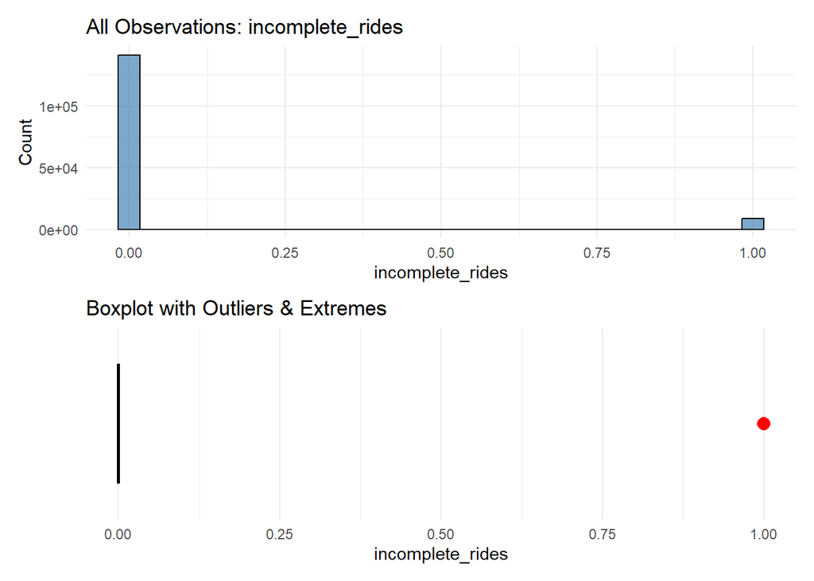

```
🟠 Atípicos (Outliers) en incomplete_rides :  9000
   🔸 Proporción (%): 6 %

🔴 Extremos (Extreme values) en incomplete_rides :  9000
   🔻 Proporción (%): 6 %
```

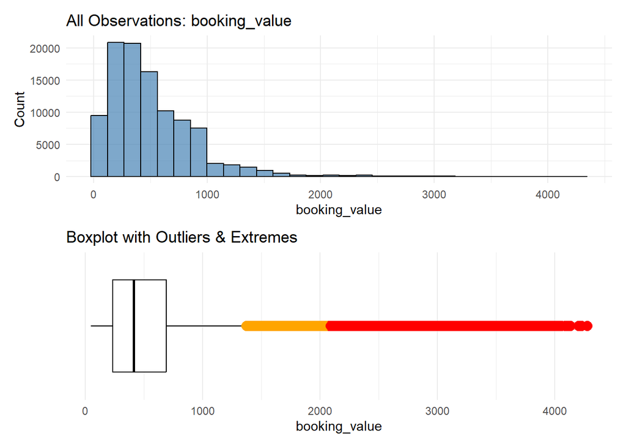

```
🟠 Atípicos (Outliers) en booking_value :  3435
   🔸 Proporción (%): 3.37 %

🔴 Extremos (Extreme values) en booking_value :  911
   🔻 Proporción (%): 0.89 %
```

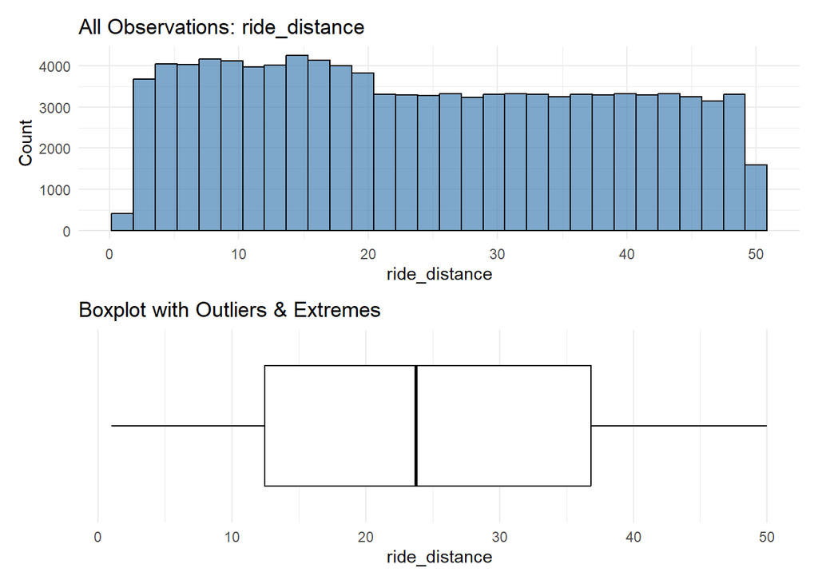

```
🟠 Atípicos (Outliers) en ride_distance :  0
   🔸 Proporción (%): 0 %

🔴 Extremos (Extreme values) en ride_distance :  0
   🔻 Proporción (%): 0 %
```

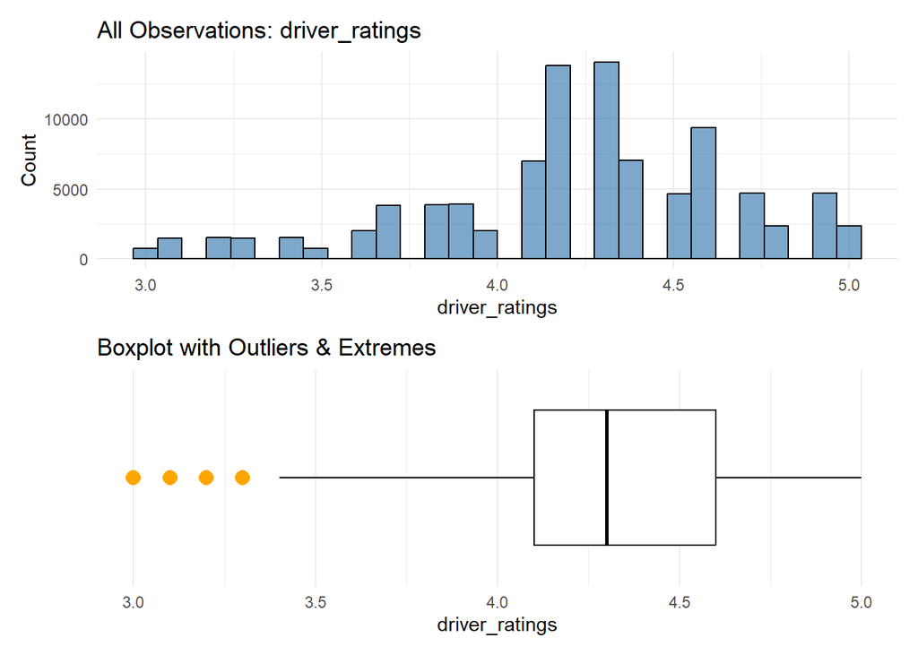

```
🟠 Atípicos (Outliers) en driver_ratings :  5203
   🔸 Proporción (%): 5.59 %

🔴 Extremos (Extreme values) en driver_ratings :  0
   🔻 Proporción (%): 0 %
```

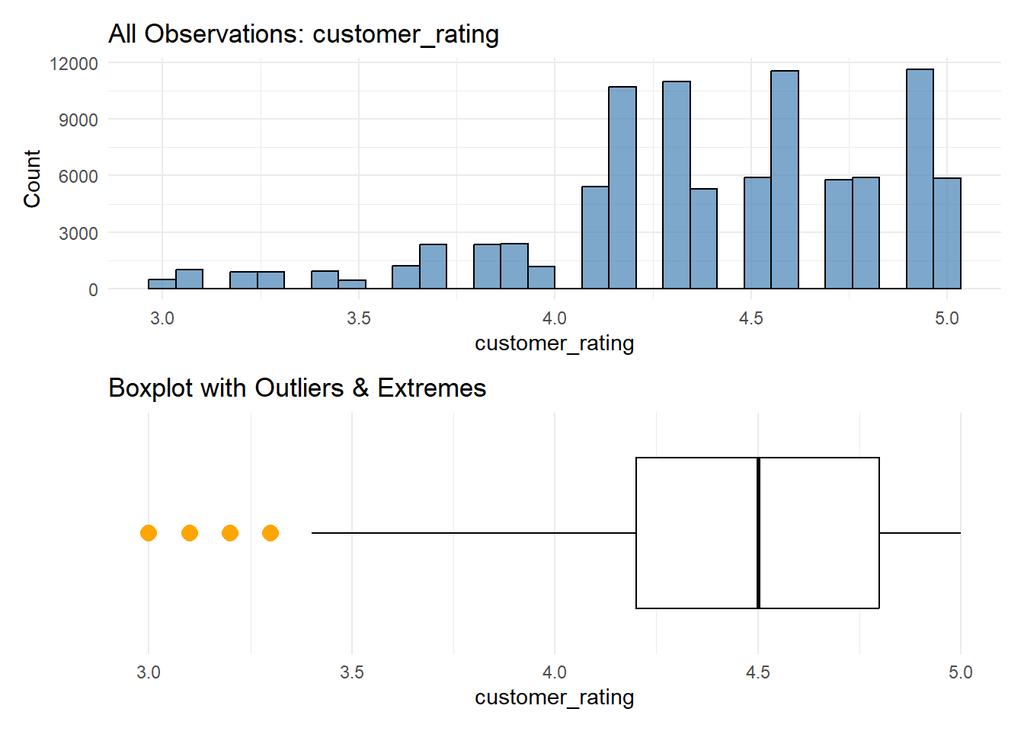

```
🟠 Atípicos (Outliers) en customer_rating :  3257
   🔸 Proporción (%): 3.5 %

🔴 Extremos (Extreme values) en customer_rating :  0
   🔻 Proporción (%): 0 %
```

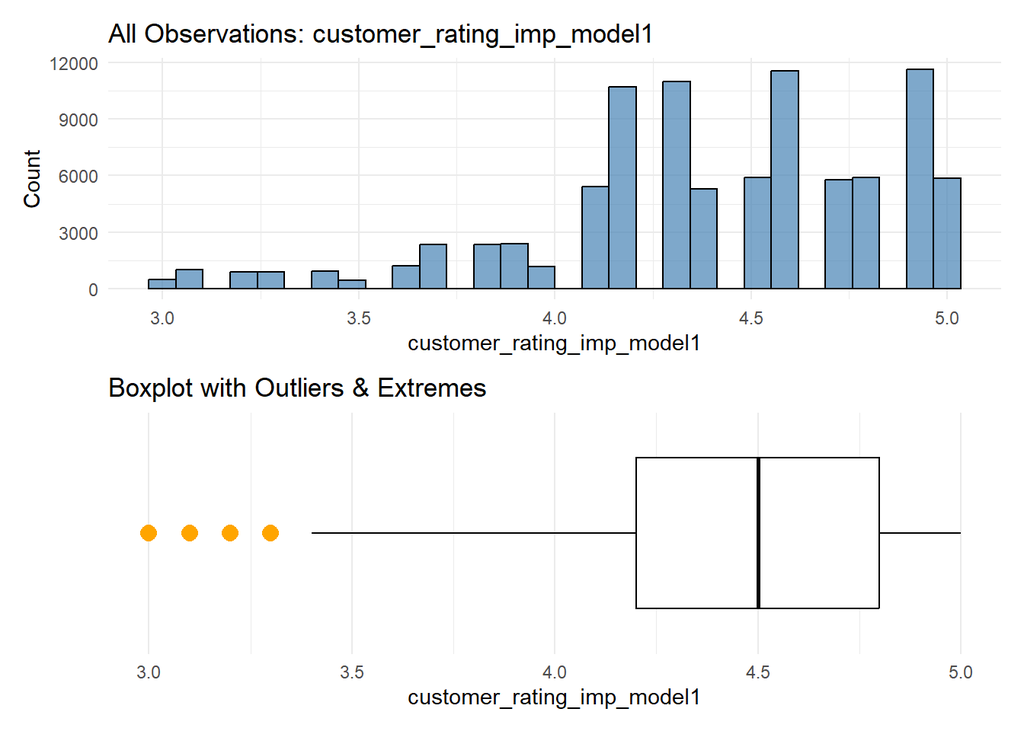

```
🟠 Atípicos (Outliers) en customer_rating_imp_model1 :  3257
   🔸 Proporción (%): 3.5 %

🔴 Extremos (Extreme values) en customer_rating_imp_model1 :  0
   🔻 Proporción (%): 0 %
```

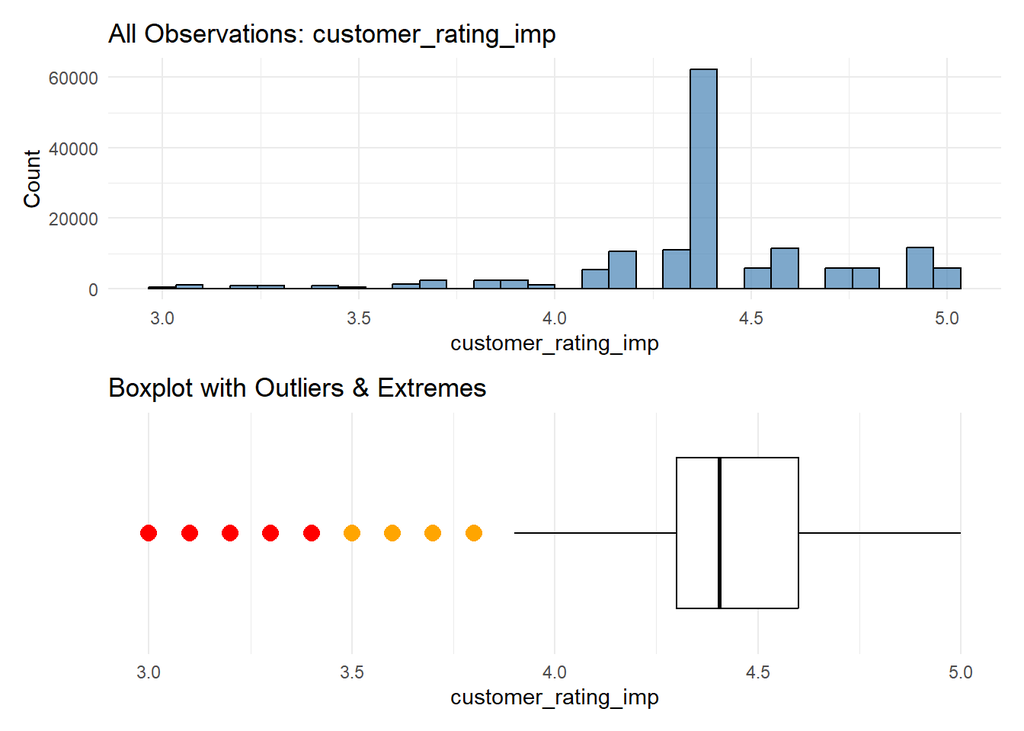

```
🟠 Atípicos (Outliers) en customer_rating_imp :  10533
   🔸 Proporción (%): 7.02 %

🔴 Extremos (Extreme values) en customer_rating_imp :  4185
   🔻 Proporción (%): 2.79 %
```

```r
source('Funciones_propias.R')
# Obtención de los nombres de las columnas numéricas
numeric_vars <- names(data)[sapply(data, is.numeric)]

# Uso de una función propia para pasar 'data' y el 'nombre'
outliers_results <- lapply(numeric_vars, function(v) outliers_extreme(data, v))
```

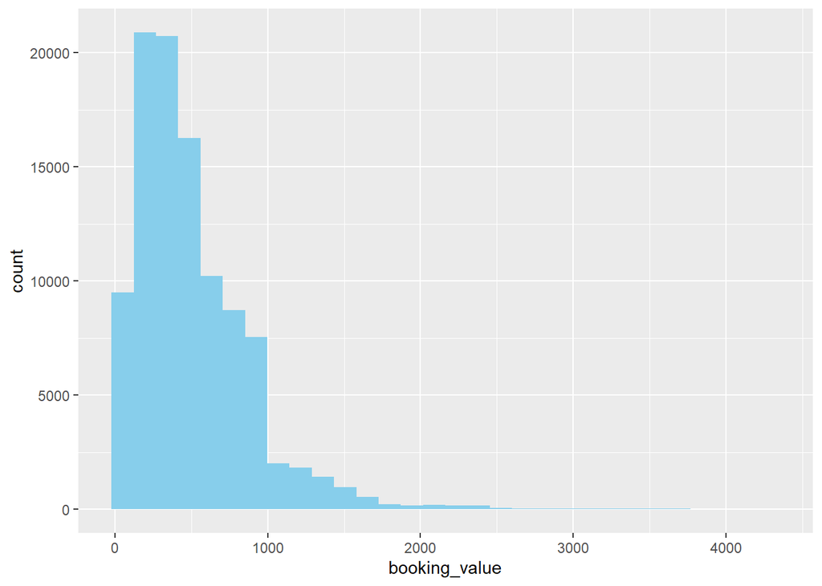

```r
ggplot(data, aes(x=booking_value)) +
  geom_histogram(fill = "skyblue")
```

Para hacer el análisis univariante se ha utilizado una función adicional para ver los extremos y outliers de cada variable junto con el porcentaje que representa.

Primeramente, se puede ver que la variable ‘booking_value’ tiene 3.435 ‘outliers’ a primera vista (3,37%), y una cantidad de 911 valores extremos (0,89%). La distribución es asimétrica con cola larga con una alta concentración de valores en rangos bajos y una cola larga que se extiende hacia valores elevados. El boxplot identifica un número considerable de observaciones fuera del rango intercuartílico, lo que indica la presencia de múltiples outliers según el criterio estadístico del IQR. A diferencia de otras variables como las valoraciones, estos valores extremos no pueden descartarse automáticamente como observaciones válidas poco frecuentes, ya que podrían corresponder tanto a casos reales (por ejemplo, viajes de larga distancia o tarifas elevadas) como a posibles inconsistencias en los datos. Por tanto, estos valores requieren un análisis más detallado en etapas posteriores para determinar su naturaleza y decidir el tratamiento más adecuado.

Por otro lado, las variables ‘driver_ratings’ y ‘customer_rating’ también cuentan con posibles outliers a primera vista representando un 5,59% y 3,5% respectivamente. Aunque el boxplot identifica valores bajos como outliers según el criterio estadístico del IQR, estos se encuentran dentro del rango válido de la variable (1–5). Por tanto, no pueden considerarse valores atípicos en términos reales, sino observaciones poco frecuentes debido a la concentración de valoraciones en rangos altos.

# 6. Análisis bivariante

Para poder ver si los outliers de la variable ‘booking_value’ tienen algún tipo de asociación con otra variable, se realizarán a continuación varios gráficos para identificar claramente las posibles relaciones.

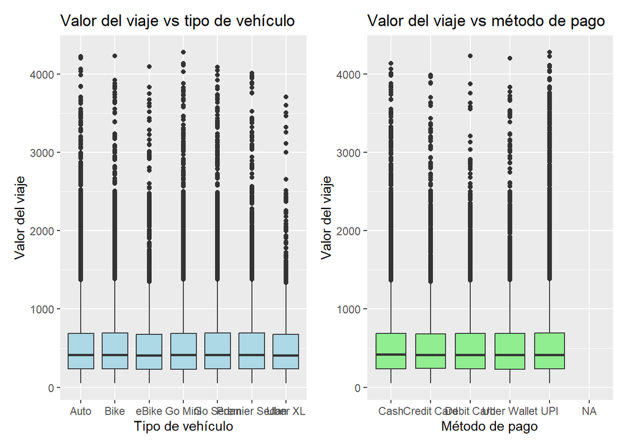

```r
# Gráfico 1: Booking Value por tipo de vehículo
p1 <- ggplot(data, aes(x = vehicle_type, y = booking_value)) +
  geom_boxplot(fill = "lightblue") +
  labs(title = "Valor del viaje vs tipo de vehículo", x = "Tipo de vehículo", y = 'Valor del viaje')

# Gráfico 2: Pressure Height por día de la semana
p2 <- ggplot(data, aes(x = payment_method, y = booking_value)) +
  geom_boxplot(fill = "lightgreen") +
  labs(title = "Valor del viaje vs método de pago", x = "Método de pago", y = "Valor del viaje")

# Combinar ambos gráficos en una fila
p1 + p2
```

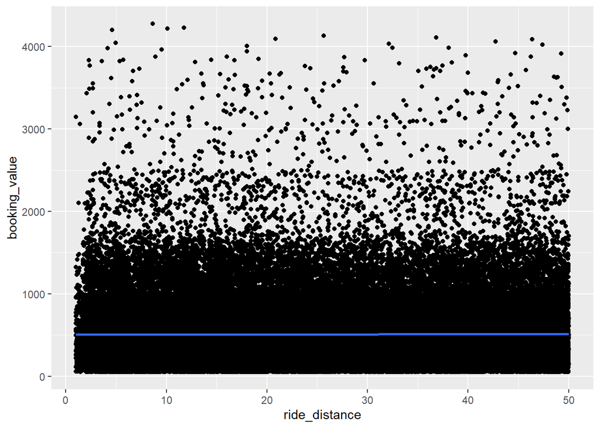

```r
# GRÁFICOS CON VARIABLES CUANTITATIVAS
ggp <- ggplot(data,aes(y = booking_value, x = ride_distance)) + geom_point()
ggp + stat_smooth(method = "lm",
                  formula = y ~ x,
                  geom = "smooth")
```

```r
summary(lm(data$booking_value~data$ride_distance))
```

```
Call:
lm(formula = data$booking_value ~ data$ride_distance)

Residuals:
   Min     1Q Median     3Q    Max
-461.9 -274.3  -94.5  180.1 3771.0

Coefficients:
                    Estimate Std. Error t value Pr(>|t|)
(Intercept)        504.69261    2.50816 201.220   <2e-16 ***
data$ride_distance   0.14626    0.08851   1.652   0.0984 .
---
Signif. codes:  0 '***' 0.001 '**' 0.01 '*' 0.05 '.' 0.1 ' ' 1

Residual standard error: 395.8 on 101998 degrees of freedom
  (48000 observations deleted due to missingness)
Multiple R-squared:  2.677e-05, Adjusted R-squared:  1.697e-05
F-statistic: 2.731 on 1 and 101998 DF,  p-value: 0.09845
```

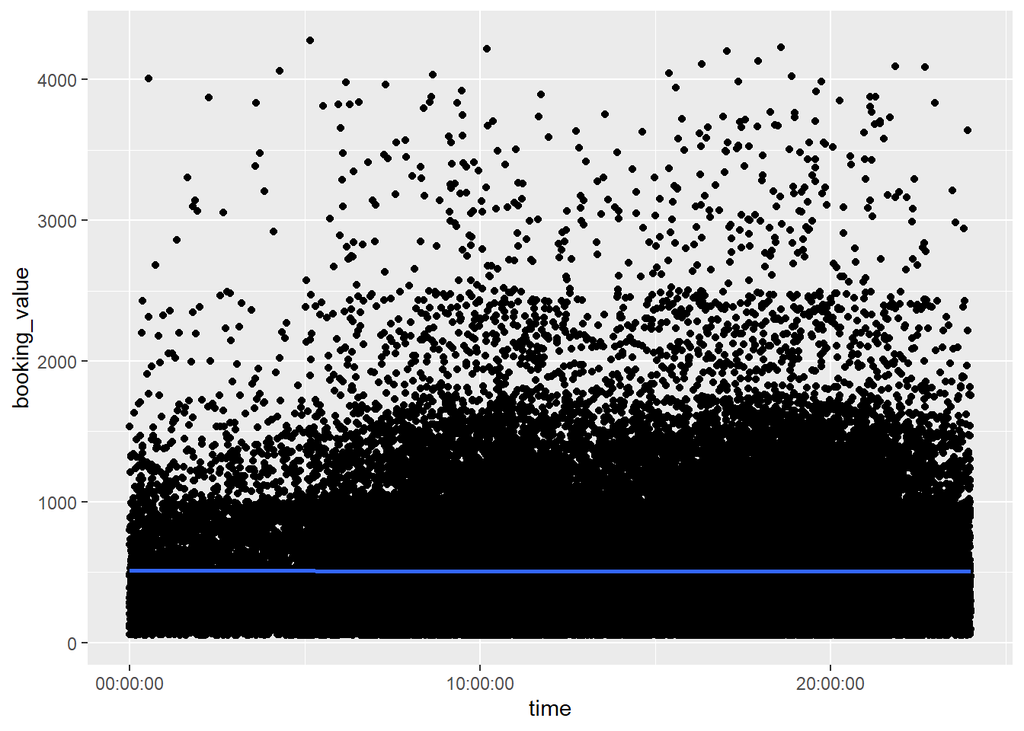

```r
ggp2 <- ggplot(data,aes(y = booking_value, x = time)) + geom_point()
ggp2 + stat_smooth(method = "lm",
                  formula = y ~ x,
                  geom = "smooth")
```

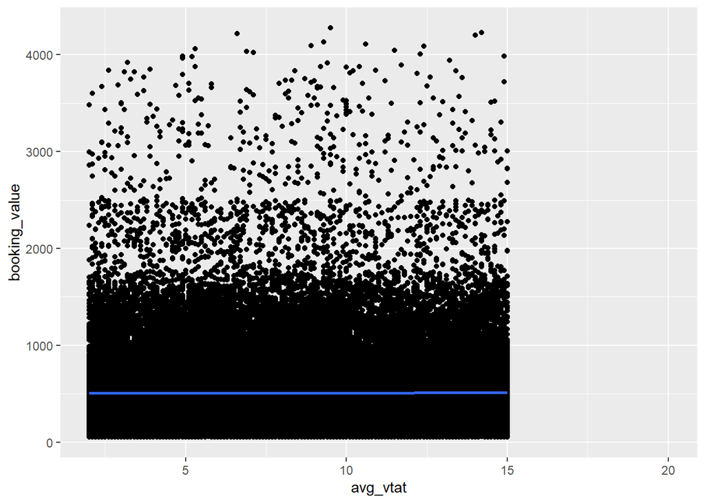

```r
ggp3 <- ggplot(data,aes(y = booking_value, x = avg_vtat)) + geom_point()
ggp3 + stat_smooth(method = "lm",
                  formula = y ~ x,
                  geom = "smooth")
```

Tras relacionar la variable del valor del viaje y la distancia no hay ninguna relación. El modelo de regresión tiene un R^2 de un valor muy bajo, y el resto de valores también son muy malos. Esto es extraño porque normalmente el valor de un viaje suele ir relacionado con la distancia, el tipo de vehículo o la distancia recorrida.

# 7. Análisis multivariante

```r
# Selección y escalado
datos_lof <- data |>
  select(where(is.numeric)) |>
  na.omit() |>
  select(where(~var(.) > 0))

datos_lof_scaled <- scale(datos_lof)

# Cálculo LOF
k <- round(log(nrow(datos_lof)))
lof_scores <- lof(datos_lof_scaled, minPts = k)

# Añadir scores al dataframe limpio
datos_lof <- datos_lof |>
  mutate(lof_score = lof_scores)

# Ver outliers con score > 1.5
datos_lof |>
  filter(lof_score > 1.5) |>
  arrange(desc(lof_score))
```

```
# A tibble: 0 × 9
# ℹ 9 variables: avg_vtat <dbl>, avg_ctat <dbl>, booking_value <dbl>,
#   ride_distance <dbl>, driver_ratings <dbl>, customer_rating <dbl>,
#   customer_rating_imp_model1 <dbl>, customer_rating_imp <dbl>,
#   lof_score <dbl>
```

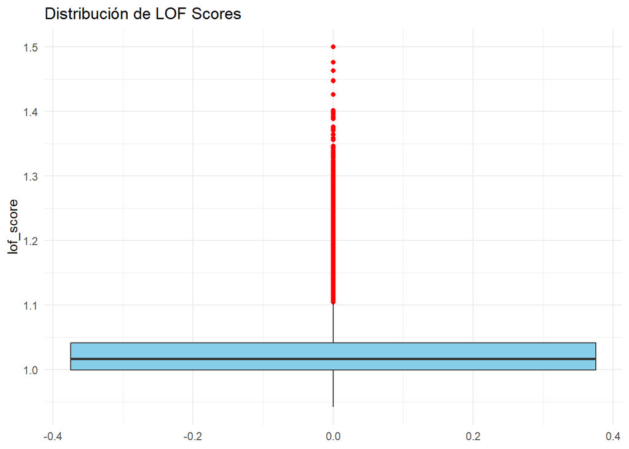

```r
# Boxplot
ggplot(datos_lof, aes(y = lof_score)) +
  geom_boxplot(fill = "skyblue", outlier.color = "red", outlier.shape = 16) +
  theme_minimal() +
  labs(title = "Distribución de LOF Scores")
```

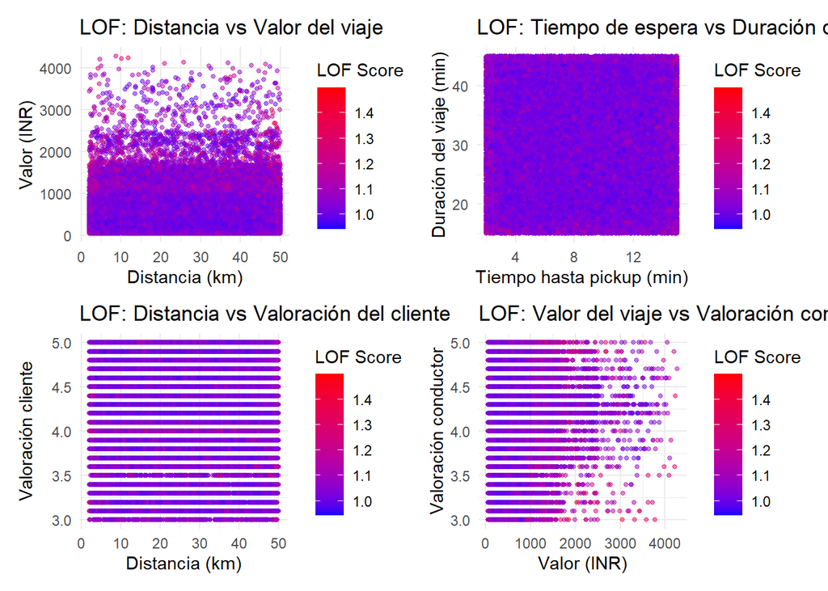

```r
p1 <- ggplot(datos_lof, aes(x = ride_distance, y = booking_value, colour = lof_score)) +
  geom_point(alpha = 0.5, size = 1) +
  scale_color_gradient(low = "blue", high = "red", name = "LOF Score") +
  theme_minimal() +
  labs(title = "LOF: Distancia vs Valor del viaje",
       x = "Distancia (km)", y = "Valor (INR)")

p2 <- ggplot(datos_lof, aes(x = avg_vtat, y = avg_ctat, colour = lof_score)) +
  geom_point(alpha = 0.5, size = 1) +
  scale_color_gradient(low = "blue", high = "red", name = "LOF Score") +
  theme_minimal() +
  labs(title = "LOF: Tiempo de espera vs Duración del viaje",
       x = "Tiempo hasta pickup (min)", y = "Duración del viaje (min)")

p3 <- ggplot(datos_lof, aes(x = ride_distance, y = customer_rating, colour = lof_score)) +
  geom_point(alpha = 0.5, size = 1) +
  scale_color_gradient(low = "blue", high = "red", name = "LOF Score") +
  theme_minimal() +
  labs(title = "LOF: Distancia vs Valoración del cliente",
       x = "Distancia (km)", y = "Valoración cliente")

p4 <- ggplot(datos_lof, aes(x = booking_value, y = driver_ratings, colour = lof_score)) +
  geom_point(alpha = 0.5, size = 1) +
  scale_color_gradient(low = "blue", high = "red", name = "LOF Score") +
  theme_minimal() +
  labs(title = "LOF: Valor del viaje vs Valoración conductor",
       x = "Valor (INR)", y = "Valoración conductor")

(p1 + p2) / (p3 + p4)
```

## 7.1 Matriz de correlaciones

```r
cor_matrix <- cor(datos_lof, use = "complete.obs")
cor_matrix
```

```
                               avg_vtat      avg_ctat booking_value
avg_vtat                    1.000000000  0.0015014266  0.0028231892
avg_ctat                    0.001501427  1.0000000000  0.0007396822
booking_value               0.002823189  0.0007396822  1.0000000000
ride_distance               0.003858046  0.0014858552  0.0056680062
driver_ratings             -0.005438787  0.0008074932 -0.0002485110
customer_rating            -0.003945394  0.0009998252 -0.0002866311
customer_rating_imp_model1 -0.003945394  0.0009998252 -0.0002866311
customer_rating_imp        -0.003945394  0.0009998252 -0.0002866311
lof_score                   0.005924328 -0.0002400343  0.2383603204
                           ride_distance driver_ratings customer_rating
avg_vtat                     0.003858046  -0.0054387866   -0.0039453938
avg_ctat                     0.001485855   0.0008074932    0.0009998252
booking_value                0.005668006  -0.0002485110   -0.0002866311
ride_distance                1.000000000  -0.0018745312    0.0045144772
driver_ratings              -0.001874531   1.0000000000   -0.0010103511
customer_rating              0.004514477  -0.0010103511    1.0000000000
customer_rating_imp_model1   0.004514477  -0.0010103511    1.0000000000
customer_rating_imp          0.004514477  -0.0010103511    1.0000000000
lof_score                   -0.001277540  -0.0395884227   -0.0788809767
                           customer_rating_imp_model1 customer_rating_imp
avg_vtat                                -0.0039453938       -0.0039453938
avg_ctat                                 0.0009998252        0.0009998252
booking_value                           -0.0002866311       -0.0002866311
ride_distance                            0.0045144772        0.0045144772
driver_ratings                          -0.0010103511       -0.0010103511
customer_rating                          1.0000000000        1.0000000000
customer_rating_imp_model1               1.0000000000        1.0000000000
customer_rating_imp                      1.0000000000        1.0000000000
lof_score                               -0.0788809767       -0.0788809767
                               lof_score
avg_vtat                    0.0059243277
avg_ctat                   -0.0002400343
booking_value               0.2383603204
ride_distance              -0.0012775400
driver_ratings             -0.0395884227
customer_rating            -0.0788809767
customer_rating_imp_model1 -0.0788809767
customer_rating_imp        -0.0788809767
lof_score                   1.0000000000
```

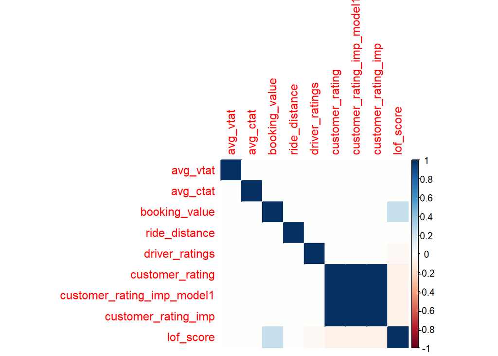

```r
library(corrplot)
corrplot(cor_matrix, method = "color")
```

No se observan correlaciones fuertes entre las variables del dataset, lo que indica baja redundancia entre ellas. Se aprecia una ligera correlación positiva entre booking_value y lof_score, lo que sugiere que valores extremos en el importe pueden ser identificados como observaciones atípicas.

Asimismo, se observa una ligera correlación negativa entre lof_score y las variables de rating, indicando que las observaciones más atípicas tienden a asociarse con valoraciones más bajas.

## 7.2 PCA o visualizaciones multivariantes

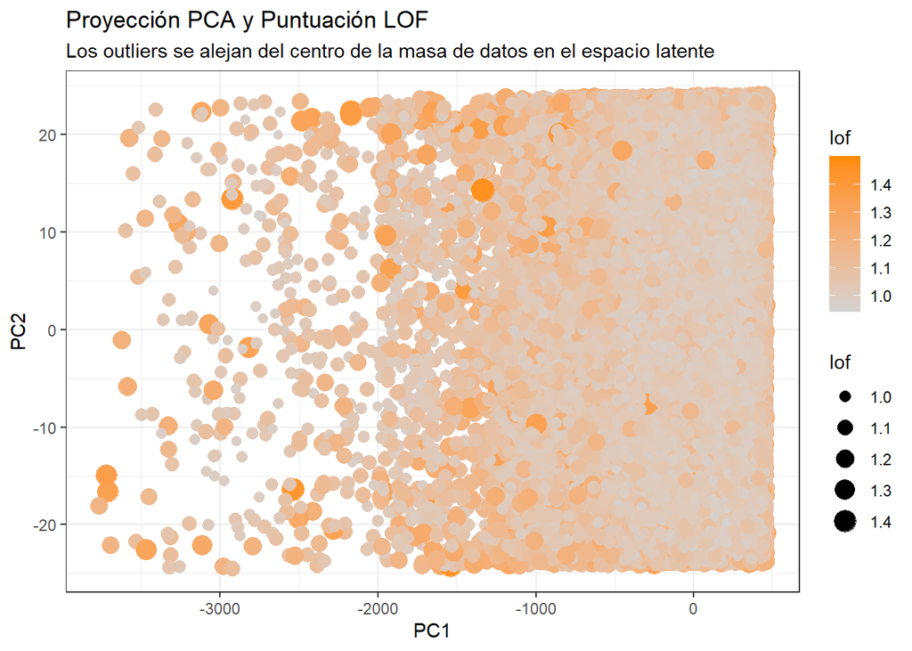

```r
# Ejecutamos un PCA rápido sobre las variables numéricas
pca_res <- prcomp(datos_lof, center = TRUE)

# Creamos un dataframe para graficar
df_pca <- as.data.frame(pca_res$x)
df_pca$lof <- lof_scores

ggplot(df_pca, aes(x = PC1, y = PC2, color = lof)) +
  geom_point(aes(size = lof)) +
  scale_color_gradient(low = "lightgrey", high = "darkorange") +
  labs(title = "Proyección PCA y Puntuación LOF",
       subtitle = "Los outliers se alejan del centro de la masa de datos en el espacio latente") +
  theme_bw()
```

```r
# Identificar índices con LOF > 1.5
indices_outliers <- which(datos_lof$lof_score > 1.5)

# Ver esos registros en el dataset original
data[indices_outliers, ]
```

```
# A tibble: 0 × 26
# ℹ 26 variables: date <date>, time <time>, booking_id <chr>,
#   booking_status <fct>, customer_id <chr>, vehicle_type <fct>,
#   pickup_location <chr>, drop_location <chr>, avg_vtat <dbl>, avg_ctat <dbl>,
#   cancelled_rides_by_customer <dbl>, reason_for_cancelling_by_customer <chr>,
#   cancelled_rides_by_driver <dbl>, driver_cancellation_reason <chr>,
#   incomplete_rides <dbl>, incomplete_rides_reason <chr>, booking_value <dbl>,
#   ride_distance <dbl>, driver_ratings <dbl>, customer_rating <dbl>, …
```

```r
# Marcar los outliers con una flag en lugar de eliminar
data <- data |>
  mutate(es_outlier_lof = booking_id %in% data[indices_outliers, ]$booking_id)
```

# 8. Conclusiones

El presente análisis exploratorio y depuración del dataset *NCR Ride Bookings* ha permitido identificar y tratar los principales problemas de calidad presentes en los datos. A continuación se resumen los hallazgos más relevantes y las decisiones tomadas.

## 8.1 Problemas de calidad detectados

Durante la fase de limpieza se identificaron varios problemas estructurales. En primer lugar, múltiples variables numéricas (`booking_value`, `ride_distance`, `avg_vtat`, `avg_ctat`, `driver_ratings`, `customer_rating`) estaban almacenadas como cadenas de texto debido a la presencia del valor `"null"` en lugar de `NA`, lo que requirió una conversión previa antes de cualquier análisis. Adicionalmente, los identificadores `booking_id` y `customer_id` contenían comillas escapadas que fueron eliminadas mediante limpieza de texto.

## 8.2 Duplicados

El análisis de duplicados a tres niveles reveló la ausencia de filas completamente idénticas y de duplicados lógicos. Sin embargo, se detectaron 1.224 `booking_id` repetidos afectando a 2.457 registros (1,6% del total), cuyos datos son completamente distintos entre sí, lo que apunta a un fallo en el sistema de generación de identificadores. Estos registros fueron marcados con una variable indicadora y conservados al no poder determinar cuál es el registro correcto.

## 8.5 Dataset final

Tras el proceso de depuración el dataset conserva sus 150.000 registros originales, enriquecido con tres variables indicadoras: `id_duplicado`, `rating_provided` y `es_outlier_lof`. Las decisiones de tratamiento adoptadas priorizan la transparencia y la trazabilidad frente a la modificación arbitraria de los datos, siguiendo los principios del análisis exploratorio riguroso.